# Week#2 :

#### *From Monday : 5th June*

#### *To Saturday : 10th of june*

## Presentation Flow

- Small Recap of previous week
- About Java Script
- About Python

# Recap

- Theoretical
- Practical

## Theoretical

- Machine Learning
- ml5.js
- Pretrained models
- LLM
- Edge Impulse

## Practical

- Image Classification
- Object detection
- Audio Detection

# About Java Script

- What is J.S ?
- What can you do with J.S ?
- What I have learnt in this week ?
- Presentation

## What is J.S ?

[figure not shown]

**JavaScript is a scripting or programming language that allows you to implement complex features on web pages — every time a web page does more than just sit there and display static information for you to look at — displaying timely content updates, interactive maps, animated 2D/3D graphics, scrolling video jukeboxes, etc. — you can bet that JavaScript is probably involved. It is the third layer of the layer cake of standard web technologies, two of which (HTML and CSS) we have covered in much more detail in other parts of the Learning Area.**

source : https://www.google.com/imgres?imgurl=https%3A%2F%2Fwww.javascripttutorial.net%2Fwp-content%2Fuploads%2F2021%2F04%2FJavaScript-Tutorial.svg&tbnid=hU9s2YTIGmF2PM&vet=12ahUKEwjp6Ybd0rr_AhVUNLcAHbdzAUgQMygAegUIARCRAQ..i&imgrefurl=https%3A%2F%2Fwww.javascripttutorial.net%2F&docid=OPjezLJLbOw5kM&w=800&h=800&q=js&ved=2ahUKEwjp6Ybd0rr_AhVUNLcAHbdzAUgQMygAegUIARCRAQ

## What can you do with J.S ?

[figure not shown]

soirce : https://cdn.educba.com/academy/wp-content/uploads/2018/10/Uses-of-JavaScript-1.jpg

## What I have learnt in this week ?

#### 1. alert

#### 2. prompt

#### 3. Data set

#### 4.Variables

#### 5.If Else

#### 6.Function

# About Python

- What is Python ?
- My Purpos of learning Python Language
- What I learnt in Python

## What is Python ?

[figure not shown]

**Python is an interpreted, object-oriented, high-level programming language with dynamic semantics. Its high-level built in data structures, combined with dynamic typing and dynamic binding, make it very attractive for Rapid Application Development, as well as for use as a scripting or glue language to connect existing components together.**

source : https://upload.wikimedia.org/wikipedia/commons/thumb/c/c3/Python-logo-notext.svg/935px-Python-logo-notext.svg.png

## My Purpose of Learning Python

- Math Oriented thinking
- Need of an hour
- Mathematical Modeling

## What I Learnt in Python

- Anaconda Navigator
- JUPYTER lab and notebook
- Presentations from jupyter notbook or lab and Markdowns
- Libraries in Python
- Streamlit

## Anaconda Navigator

What is Anaconda Navigator ? Anaconda Navigator is a desktop graphical user interface (GUI) included in Anaconda® Distribution that allows you to launch applications and manage conda packages, environments, and channels without using command line interface (CLI) commands.

### This is how Anaconda Navigator looks like :

[figure not shown]

source : https://docs.anaconda.com/_images/nav-tabs.png

## Project JuPyteR

Project Jupyter Project Jupyter is a non-profit, open-source project, born out of the IPython Project in 2014 as it evolved to support interactive data science and scientific computing across all programming languages.

What does JuPyteR stands for ? "Jupyter" is a loose acronym meaning Julia, Python, and R. These programming languages were the first target languages of the Jupyter application.

## Jupyter Notebook and Jupyter Lab

[figure not shown]

Difference Between Jupyter Notebook and Jupyter Lab Jupyter notebook only offers a very simple interface using which users can open notebooks, terminals, and text files. Jupyter lab offers a very interactive interface that includes notebooks, consoles, terminals, CSV editors, markdown editors, interactive maps, and more.

source : https://i.stack.imgur.com/nYYoU.png

## Markdowns from Jupyter Notebook or Lab

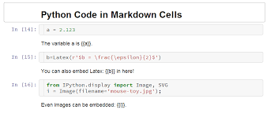

Markdown is a lightweight Markup language with a plain text syntax. John Gruber developed the Markdown language in 2004 in a collaborative effort with Aaron Swartz, intending to enable people to “write with easy-to-read and easy-to-write plain text format and potentially convert it to structurally correct XHTML (or HTML).”

source : https://www.google.com/url?sa=i&url=https%3A%2F%2Fjupyter-contrib-nbextensions.readthedocs.io%2Fen%2Flatest%2Fnbextensions%2Fpython-markdown%2Freadme.html&psig=AOvVaw1wc0iwXr3TaioDvL4KekPM&ust=1686552827984000&source=images&cd=vfe&ved=0CBEQjRxqFwoTCODN34PRuv8CFQAAAAAdAAAAABAE

## Presentations from Jupyter Notebook or Lab

We can also create presentations with the help of Jupyter Notebook or Lab . If we have to give presentation with code blocks then there is no need to take screenshots and again paste it in your presentations .

## Libraries in Python

### There are two types of libraries

- Inbuilt libraries provided by Python community
- External libraries made by other communities , for example :

Plotly express

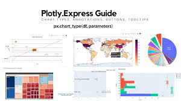

source : https://miro.medium.com/v2/resize:fit:1200/1*kg2I596jLv0JonyrHy9Jiw.png

Pandas

[figure not shown]

source : https://www.google.com/url?sa=i&url=https%3A%2F%2Fen.wikipedia.org%2Fwiki%2FPandas_%2528software%2529&psig=AOvVaw13gi7Q5vmdWi4p0Qrq-GmT&ust=1686552519618000&source=images&cd=vfe&ved=0CBEQjRxqFwoTCNj72_DPuv8CFQAAAAAdAAAAABAE

NumPy

[figure not shown]

source : https://numpy.org/images/twitter-image.jpg

SciPy

[figure not shown]

source : https://www.fullstackpython.com/img/logos/scipy.png

Matplotlib.pyplot

[figure not shown]

source : https://matplotlib.org/stable/_static/images/logo2.svg

## Streamlit

[figure not shown]

Streamlit is a free and open-source framework to rapidly build and share beautiful machine learning and data science web apps. It is a Python-based library specifically designed for machine learning engineers.

source : https://res.cloudinary.com/dyd911kmh/image/upload/v1640050215/image27_frqkzv.png